# Data 624 Homework 6

## Exercise 8

For the United States GDP series (from `global_economy`):

if necessary, find a suitable Box-Cox transformation for the data;

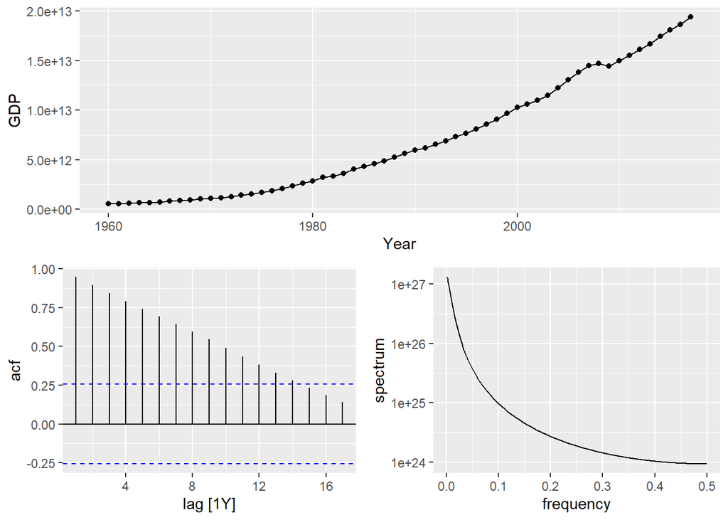

```r
us_GDP <- global_economy %>%
  filter(Country == "United States")

us_GDP %>%
  gg_tsdisplay(GDP)
```

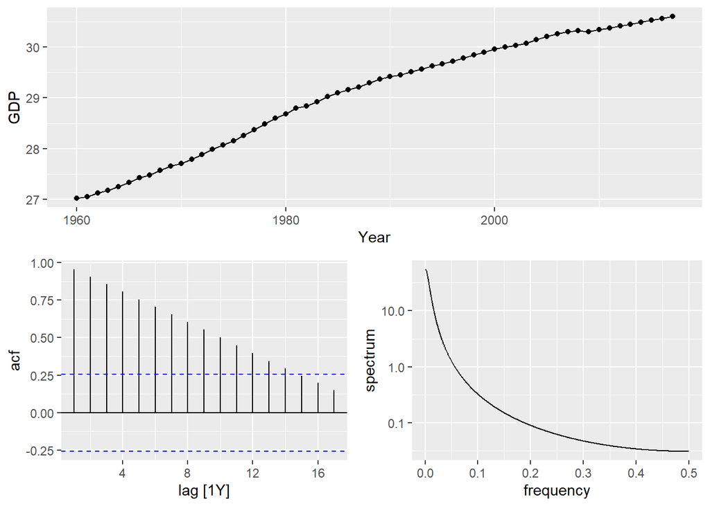

```r
us_GDP_log <- us_GDP %>%
  mutate(GDP = log(GDP))
us_GDP_log %>%
  gg_tsdisplay(GDP)
```

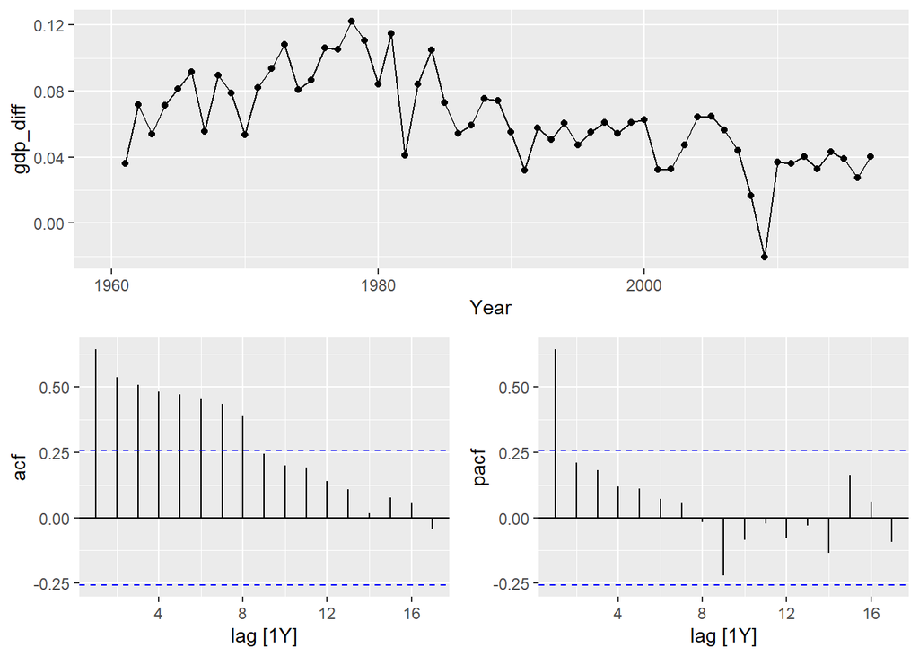

```r
us_GDP_log_d <- us_GDP_log %>%
  mutate(gdp_diff = difference(GDP,1))
us_GDP_log_d %>%
  gg_tsdisplay(gdp_diff, plot_type = 'partial')
```

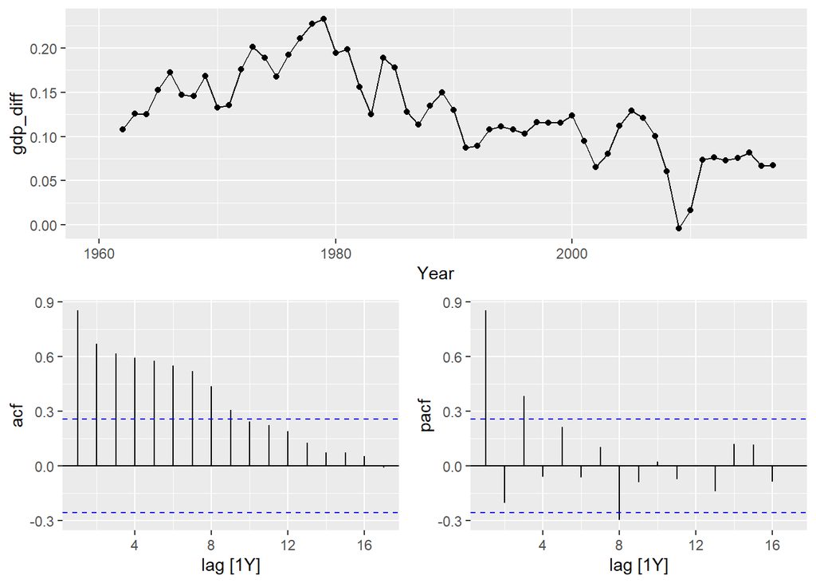

```r
us_GDP_log_d2 <- us_GDP_log %>%
  mutate(gdp_diff = difference(GDP,2))
us_GDP_log_d2 %>%
  gg_tsdisplay(gdp_diff, plot_type = 'partial')
```

fit a suitable ARIMA model to the transformed data using `ARIMA()`;

```r
gdp_fit <- us_GDP_log_d %>%
  model(ARIMA(gdp_diff))
gdp_fit
```

```
## # A mable: 1 x 2
## # Key:     Country [1]
##   Country       `ARIMA(gdp_diff)`
##   <fct>                   <model>
## 1 United States      <NULL model>
```

```r
gdp_fit %>%
  gg_tsresiduals()
```

```
## Error in na.contiguous.default(as.ts(x)): all times contain an NA
```

Same issue as before; no model produced.

try some other plausible models by experimenting with the orders chosen;

```r
gdp_fit2 <- us_GDP_log_d2 %>%
  model(ARIMA(gdp_diff))
gdp_fit2
```

```
## # A mable: 1 x 2
## # Key:     Country [1]
##   Country       `ARIMA(gdp_diff)`
##   <fct>                   <model>
## 1 United States      <NULL model>
```

```r
gdp_fit2 %>%
  gg_tsresiduals()
```

```
## Error in na.contiguous.default(as.ts(x)): all times contain an NA
```

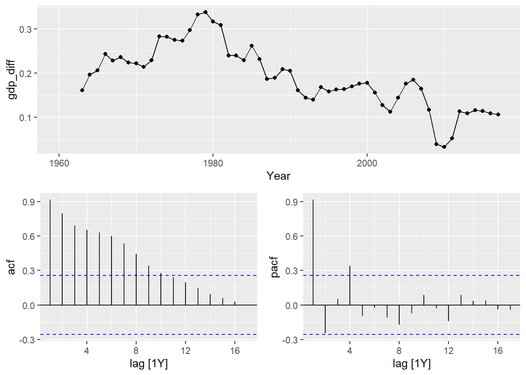

```r
us_GDP_log_d3 <- us_GDP_log %>%
  mutate(gdp_diff = difference(GDP,3))
us_GDP_log_d3 %>%
  gg_tsdisplay(gdp_diff, plot_type = 'partial')
```

```r
gdp_fit3 <- us_GDP_log_d3 %>%
  model(ARIMA(gdp_diff))
gdp_fit3
```

```
## # A mable: 1 x 2
## # Key:     Country [1]
##   Country       `ARIMA(gdp_diff)`
##   <fct>                   <model>
## 1 United States      <NULL model>
```

```r
gdp_fit3 %>%
  gg_tsresiduals()
```

```
## Error in na.contiguous.default(as.ts(x)): all times contain an NA
```

Still having issues producing ARIMA models even though the code looks fine

choose what you think is the best model and check the residual diagnostics;

```r
gdp_models <- us_GDP_log %>%
  model(one = ARIMA(GDP ~ 1 + pdq(0,1,1)),
        two = ARIMA(GDP ~  pdq(0,2,0)),
        three= ARIMA(GDP ~ 1 + pdq(1,1,1)))
glance(gdp_models) %>%
  arrange(AICc) %>%
  select(.model:BIC)
```

```
## # A tibble: 3 × 6
##   .model   sigma2 log_lik   AIC  AICc   BIC
##   <chr>     <dbl>   <dbl> <dbl> <dbl> <dbl>
## 1 three  0.000414    143. -278. -278. -270.
## 2 two    0.000539    133. -263. -263. -261.
## 3 one    0.000552    134. -263. -262. -257.
```

produce forecasts of your fitted model. Do the forecasts look reasonable?

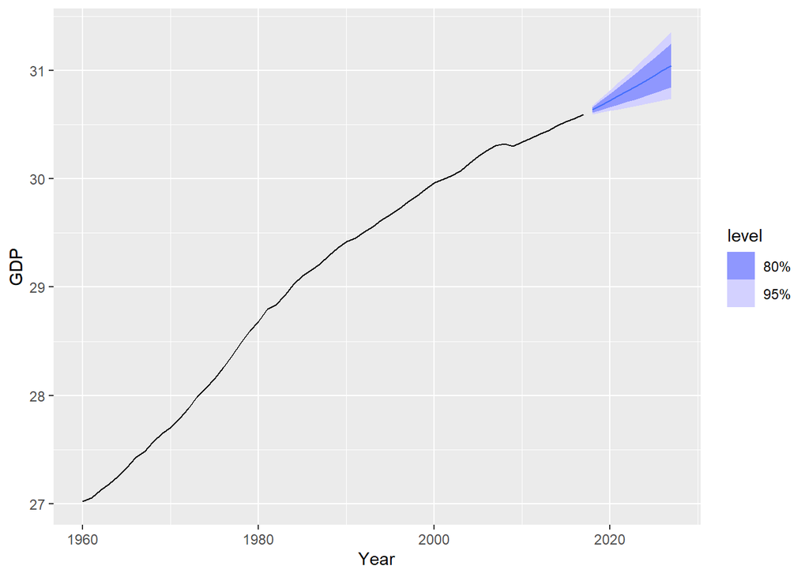

```r
gdp_models %>%
  forecast(h=10) %>%
  filter(.model=='three') %>%
  autoplot(us_GDP_log)
```

compare the results with what you would obtain using `ETS()` (with no transformation).

```r
ets <- us_GDP %>%
  model(ETS(GDP))

report(ets)
```

```
## Series: GDP
## Model: ETS(M,A,N)
##   Smoothing parameters:
##     alpha = 0.9990876
##     beta  = 0.5011949
##
##   Initial states:
##          l[0]        b[0]
##  448093333334 64917355687
##
##   sigma^2:  7e-04
##
##      AIC     AICc      BIC
## 3190.787 3191.941 3201.089
```

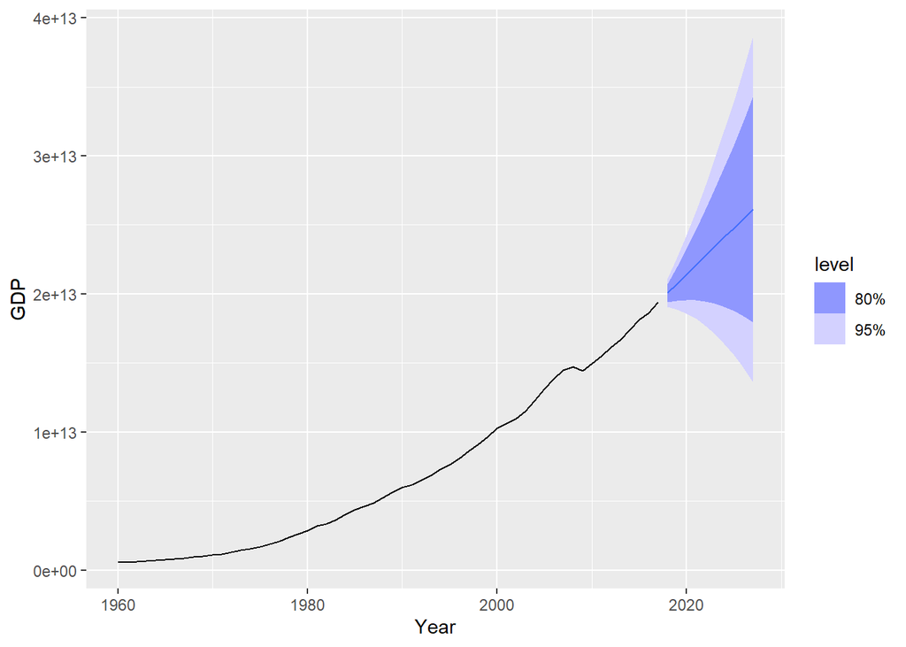

```r
ets %>%
  forecast(h=10) %>%
  autoplot(us_GDP)
```

## Works Cited

9.11 Exercises | Forecasting: Principles and Practice (3rd ed). (2025). Otexts.com. https://otexts.com/fpp3/arima-exercises.html